# Lab 2 - Intro to R Markdown and ggplot2

In this lab, you will learn how to make effective visualizations, focusing especially on the `ggplot2` package.

## Creating reproducible lab reports

Reproducibility is important in scientific research, since others might want to verify your report. We will be using R Markdown on this assignment. You can download a template using the below code.

```r
download.file("https://jacobfhsmith.github.io/STA101-Fall-2021/sta101_lab2.Rmd", destfile="sta101_lab2.Rmd")
```

You can also create your own R Markdown file by going to File–> New File –> R Markdown above.

A helpful tutorial for R Markdown that Evan Knox, a PhD student who served as head TA for STA 101, in Spring 2021 made in a previous semester is available [here](https://github.com/jacobfhsmith/STA101L-Spring2021/blob/main/STA%20101%20RMarkdown%20Tutorial.pptx?raw=true).

## Load and view data

First, we need to read our data into R and view it. Here, we again load data from packages. Next week, we will discuss how to load external data.

The `sleep` data set is a built-in data set from package named `datasets`. This data set tracks the change in patients’ sleep after being given different medications. You can access it by loading the package using the `library` command.

```r
library(datasets)
head(sleep)
```

```
##   extra group ID
## 1   0.7     1  1
## 2  -1.6     1  2
## 3  -0.2     1  3
## 4  -1.2     1  4
## 5  -0.1     1  5
## 6   3.4     1  6
```

The `head()` function outputs the first 6 lines of a data set by default. (You can specify that the function show a different number of rows.)

The `tail()` function outputs the last 6 rows of a data set.

```r
tail(sleep)
```

```
##    extra group ID
## 15  -0.1     2  5
## 16   4.4     2  6
## 17   5.5     2  7
## 18   1.6     2  8
## 19   4.6     2  9
## 20   3.4     2 10
```

The summary() function gives you summary statistics of the data set, such as the mean or median for numeric variables and frequency for categorical variables.

```r
summary(sleep)
```

```
##      extra        group        ID
##  Min.   :-1.600   1:10   1      :2
##  1st Qu.:-0.025   2:10   2      :2
##  Median : 0.950          3      :2
##  Mean   : 1.540          4      :2
##  3rd Qu.: 3.400          5      :2
##  Max.   : 5.500          6      :2
##                          (Other):8
```

## Visualizations

Here we will use the mtcars data set in the `datasets` package. There are a variety of ways to plot data in R. I provide an example of the simple `plot` command below, but for the rest of this lab, we will focus on using `ggplot2`.

(Note: When calling data, you can either use `data = mtcars` or type `mtcars$mpg~mtcars$wt`. [This](https://libraryguides.mcgill.ca/c.php?g=699776&p=4968546) resource discusses common operators in R that may be helpful as a reference.)

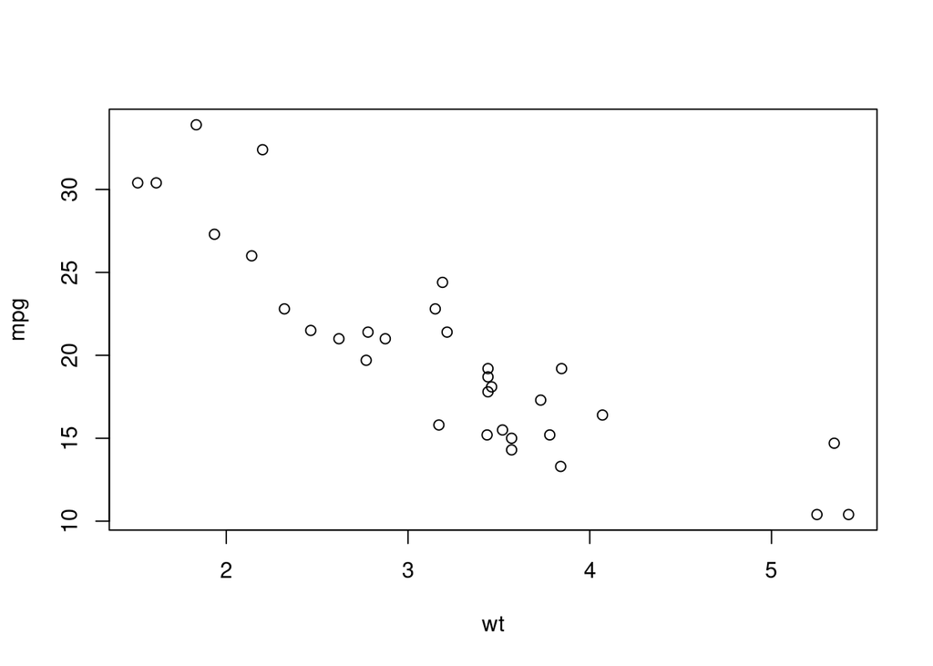

```r
plot(mpg ~ wt, data = mtcars) # formula notation
```

Now, let’s use `ggplot2` to make a (in my opinion) more aesthetically pleasing version of this plot.

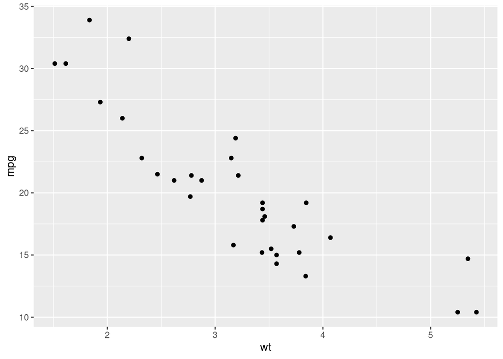

```r
# Using ggplot:
library(ggplot2)
ggplot(mtcars, aes(x = wt, y = mpg)) +
  geom_point()
```

### Basics of ggplot

The `ggplot2` package has seven aspects, but we are going to focus mostly on the first three of the below for this lab:

- Data
- Aesthetics
- Geometries
- Facets
- Statistics
- Coordinates
- Themes

Think about each aspect as a layer of your plot.

The first layer is your data, which makes sense intuitively, since you need to tell R which data set you are drawing from.

The second layer is aesthetics or mapping, which is how you want to plot the data, i.e., which variables you will use. It is specified inside `aes()`.

Finally, you should decide which kind of plot you want for your data, such as a scatter plot, histogram, box plot, or bar plot.

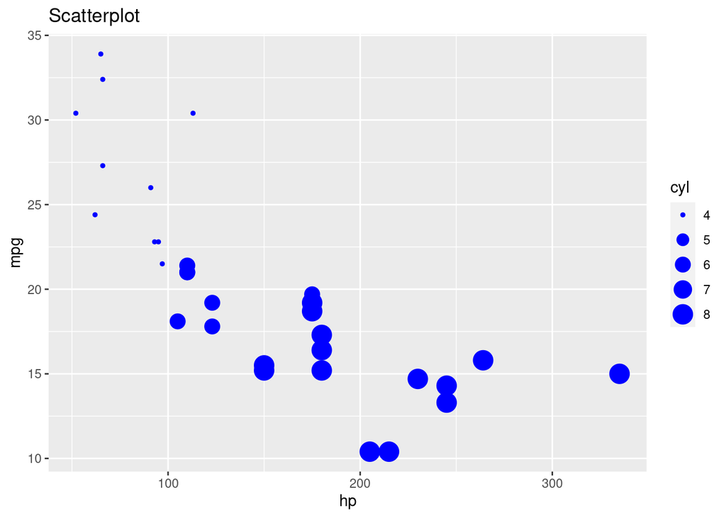

```r
ggplot(data = mtcars, aes(x = hp, y = mpg, size = cyl)) +
  geom_point(color = 'blue') +
  ggtitle("Scatterplot")
```

### Examples

#### Scatterplot

Scatter plots are best for showing a relationship between two numeric variables, as shown above.

#### Histogram

Histograms are used to display the distribution of numeric variables. Here, you will plot the variable of interest on the x-axis. The y-axis will show the frequency of the variable. You can adjust the plot with bin or binwidth.

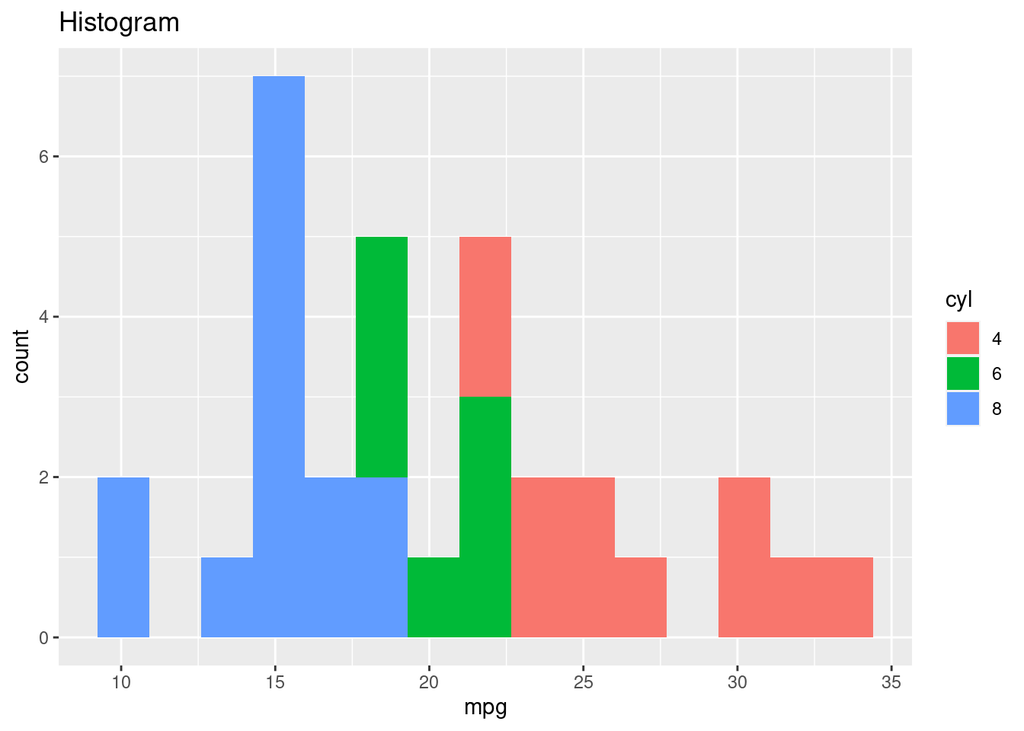

```r
mtcars$cyl = as.character(mtcars$cyl)
ggplot(data = mtcars, aes(x = mpg, fill = cyl)) +
  geom_histogram(bins = 15) +
  ggtitle("Histogram")
```

#### Dot plots and box plots

Dot plots are useful when you want to show the distribution of either numeric or categorical variables.

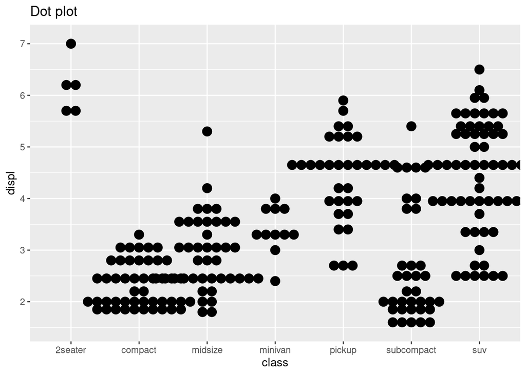

```r
ggplot(mpg, aes(x = class, y = displ)) +
  geom_dotplot(binaxis='y', stackdir='center') +
  ggtitle("Dot plot")
```

Box plots are another way of showing distribution of numeric variables, with the 1st and 3rd quartiles represented by the edges of the box.

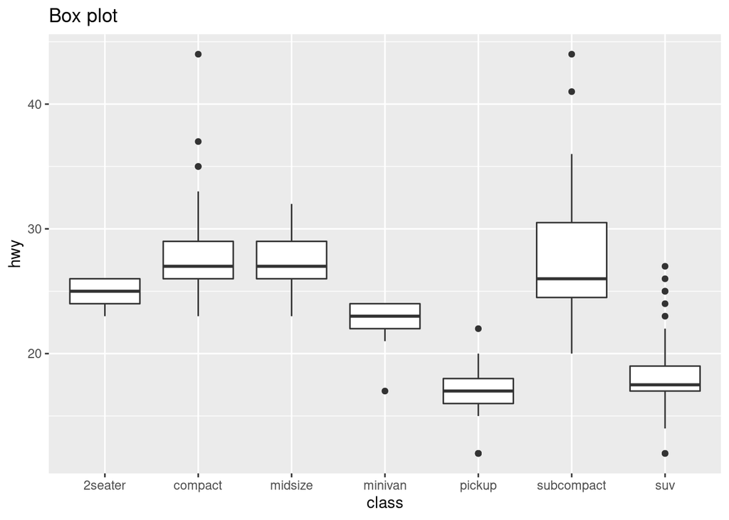

```r
ggplot(mpg, aes(x = class, y = hwy)) +
  geom_boxplot() +
  ggtitle("Box plot")
```

#### Bar plot

A bar plot illustrates data in rectangular bars with length of the bar proportional to the value of the variable.

Below, we use `dplyr` to manipulate the data. Both `ggplot2` and `dplyr` are `tidyverse` packages.

You will learn more about this package in next week’s lab (and in class on Monday the 6th), but [here](https://rstudio.com/wp-content/uploads/2015/02/data-wrangling-cheatsheet.pdf) is a cheat sheet for how to use this package.

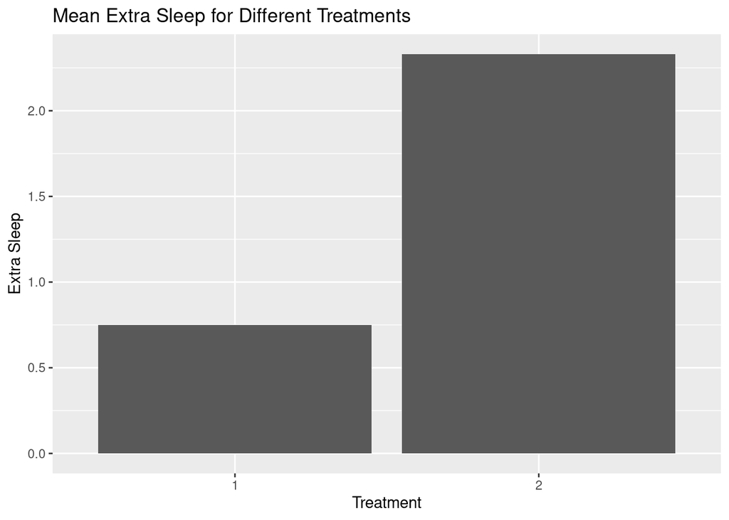

```r
library(dplyr)
sleep_mean = sleep %>%
  group_by(group) %>%
  summarise(Mean_extra_sleep = mean(extra))

ggplot(data = sleep_mean, aes(x = group, y = Mean_extra_sleep)) +
  geom_bar(stat="identity") +
  ggtitle("Mean Extra Sleep for Different Treatments") +
  labs(x = "Treatment", y = "Extra Sleep")
```

#### Density plot

Density plots are a continuous version of a histogram. They convey the same information, the distribution of numeric variables. Instead of bins, density plots use a kernel density estimate (smooth curve) to represent the distribution. If you compare the density plot with the histogram, you can see they are showing the same thing.

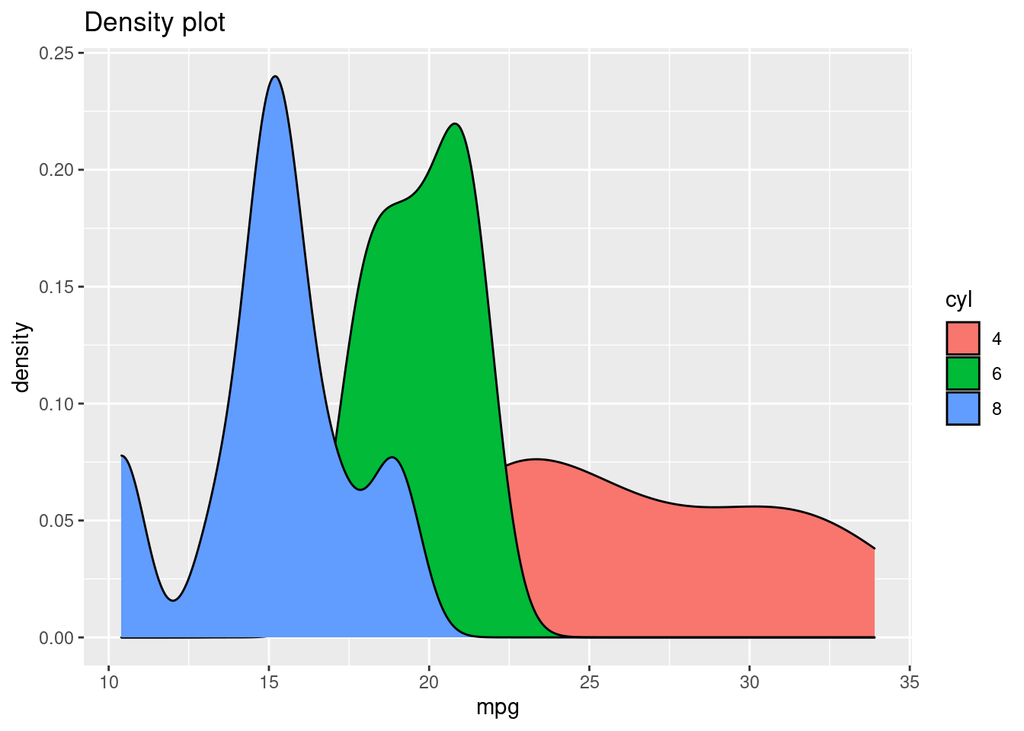

```r
ggplot(data = mtcars, aes(x = mpg, fill = cyl)) + geom_density() + ggtitle("Density plot")
```

As a reminder, if you don’t know something about a function or a package, use ? followed by the name of the function or package and R will give you documentation about it. Google is also a great resource for finding information about R, as is [Stack Overflow](https://stackoverflow.com/).

## Exercises:

### 1 (20% of grade)

First, please install the [Palmer’s Penguin](https://allisonhorst.github.io/palmerpenguins/) package (`palmerpenguin`). This package contains two data sets, but here we are going to focus on the `penguins` data set.

Then, please call the FiveThirtyEight (`fivethirtyeight`) package from your library again. This package has many data sets, but I would suggest focusing on the [Candy Rankings](https://fivethirtyeight.com/videos/the-ultimate-halloween-candy-power-ranking/) data set (`candyrankings`).

After loading these packages, please investigate and discuss what you observe in the first and last few rows and find summary statistics for the two data sets I suggest above. (Hint, the link above to the Palmer’s Penguin data set may be helpful here.) You do not need to discuss every summary statistic you find, just please show that you know the command to find them.

10% for correctly reading in data sets 10% for investigating the data

### 2 (20% of grade)

Using one of the data sets you just read in, please plot a scatter plot for two continuous variables in it and describe the relationship you observe. Comment on the relationship. Is it what you would have expected before you made the plot?

10% for a correct scatter plot 10% description of relationship

### 3 (20% of grade)

Please choose a continuous variable in one of the data sets and plot both a density plot and histogram.

10% for a correct histogram 10% for a correct density plot

### 4 (20% of grade)

Please choose a continuous variable and a categorical variable in one of the data sets. Calculate the medians of that continuous variable for each category and make a bar plot for these medians.

10% for calculating the medians 10% for a correct bar plot

### 5 (20% of grade)

Please choose a continuous variable and a categorical variable in one of the data sets. Make a box plot for that continuous variable across all categories. Do the same thing for a dot plot. You may either do these both on the same graph or side by side.

10% for a correct box plot 10% for a correct dot plot

Reference

- [Palmer’s Penguin](https://allisonhorst.github.io/palmerpenguins/) package
- [FiveThirtyEight Package](https://cran.r-project.org/web/packages/fivethirtyeight/vignettes/fivethirtyeight.html)

This lab was modified from a lab made by Daniel Deng for a previous semester.